# Weighted vs Unweighted

Brett Stacy

2024-06-28

# Compare weighted vs unweighted proportions at length EBS Pcod

Let’s take a look at how weighting (expanding) changes the unweighted (nominal) proportions at length.

## Load in necessary data

This data was saved from my version of the EBS Pcod expansion.

```r
# y2 = readRDS(file = "C:/Users/bstacy2/OneDrive - UW/UW Postdoc/GitHub Repos/y2_ebs_pcod_Brett.RDS")
# y7 = readRDS(file = "C:/Users/bstacy2/OneDrive - UW/UW Postdoc/GitHub Repos/y7_ebs_pcod_Brett.RDS")
y2 = readRDS(file = "C:/Users/bstacy2/OneDrive - UW/UW Postdoc/GitHub Repos/baseISS_data/inputs/y2_ebs_pcod_Brett.RDS")
y7 = readRDS(file = "C:/Users/bstacy2/OneDrive - UW/UW Postdoc/GitHub Repos/baseISS_data/inputs/y7_ebs_pcod_Brett.RDS")

library(tidyverse)
library(data.table)
```

## Calculate the nominal proportions at length

```r
y3<- y2[,c("YEAR","GEAR","AREA2","MONTH","CRUISE",
             "HAUL_JOIN", "LENGTH", "SUM_FREQUENCY", "YAGMH_SNUM",
             "YAGMH_SFREQ","YAGM_SFREQ", "YG_SFREQ","Y_SFREQ","YAGM_TNUM","YG_TNUM","Y_TNUM","YAGMH_SNUM",
             "YAGM_SNUM","YG_SNUM","YG_SNUM","Y_SNUM","WEIGHT1","WEIGHT2","WEIGHT3","WEIGHT4")]     # get rid of some unneeded variables

  y3$WEIGHTX<-y3$WEIGHT1

  y4<-y3[YAGM_SFREQ>30][,list(WEIGHT=sum(WEIGHTX)),by=c("LENGTH","YEAR")]  ## setting minumal sample size to 30 lengths for Year, area, gear, month strata. # sample size here means haul numbers of fish, not observer sample number. this reduced nrow by about 1000. this line also creates a new variable WEIGHT, which is the sum of WEIGHTX across length and year. i.e., the weight of each length for every year.

  y5<-y4[,list(TWEIGHT=sum(WEIGHT)),by=c("YEAR")] # TWEIGHT is I think the total weight summed across length bins for every year. sum(TWEIGHT) = 1.9. Shouldn't this sum to 1??
  y5=merge(y4,y5) # merge the individual length weights with their respective year weights.
  y5$FREQ<-y5$WEIGHT/y5$TWEIGHT # RESULT! This is the preliminary proportions at length. They sum to 1 for every year. the FREQuency, or relative weight, between length bins to the total annual weight.
  y6<-y5[,-c("WEIGHT","TWEIGHT")] # saving a version with just FREQ

  grid<-data.table::data.table(expand.grid(YEAR=unique(y5$YEAR),LENGTH=1:max(y5$LENGTH))) # make a grid for every year, have a length bin by centemeter from 1 to max length
  y7.nom<-merge(grid,y6,all.x=TRUE,by=c("YEAR","LENGTH")) # merge the grid with y6, which is the expanded frequency of proportions for each length bin observed for each year.
y7.nom[is.na(FREQ)]$FREQ <-0                                  # RESULT! ## this is the proportion at length for an aggregated-gear fishery. # The NAs are where there were no observations for that length bin in that year so call them zero. This is what must be input into the assessment model.
```

## Isolate the expanded proportions at length

```r
year = 2011

y7[YEAR==year, FREQ] %>% sum()
```

```
## [1] 1
```

```r
expanded = y7[YEAR==year, ]
nominal = y7.nom[YEAR==year, ]
```

## Density Plot

Don’t use

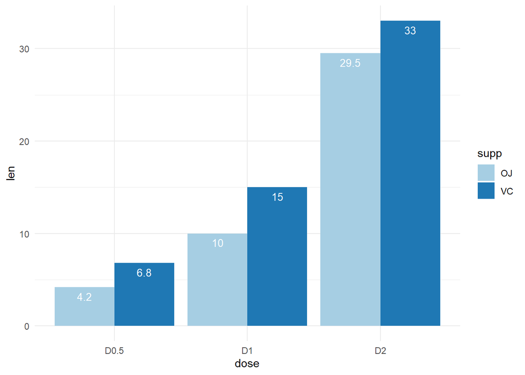

```r
df2 <- data.frame(supp=rep(c("VC", "OJ"), each=3),
                dose=rep(c("D0.5", "D1", "D2"),2),
                len=c(6.8, 15, 33, 4.2, 10, 29.5))

ggplot(data=df2, aes(x=dose, y=len, fill=supp)) +
  geom_bar(stat="identity", position=position_dodge())+
  geom_text(aes(label=len), vjust=1.6, color="white",
            position = position_dodge(0.9), size=3.5)+
  scale_fill_brewer(palette="Paired")+
  theme_minimal()
```

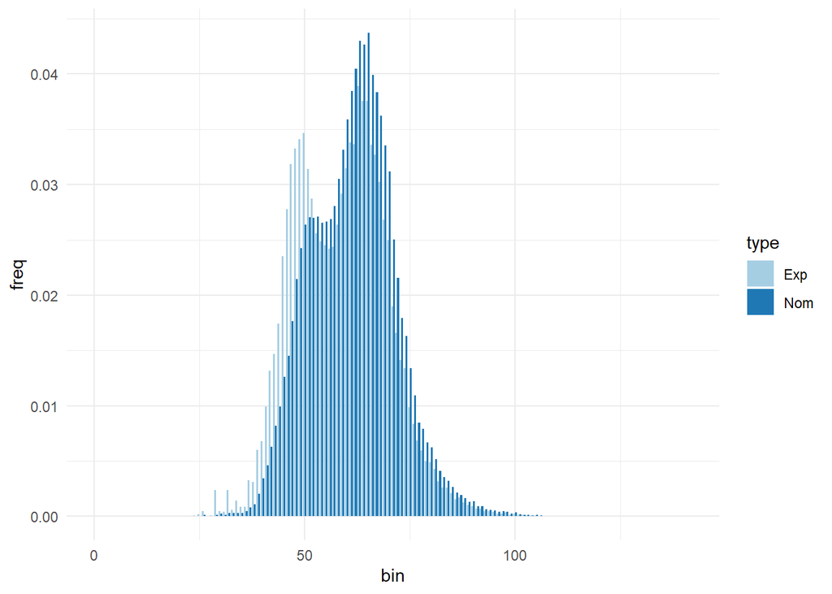

```r
# mine
df = data.frame(type = rep(c("Nom", "Exp"), each = nrow(expanded)),
                bin = rep(expanded$LENGTH, 2),
                freq = c(nominal$FREQ, expanded$FREQ))

ggplot(data=df, aes(x=bin, y=freq, fill=type)) +
  geom_bar(stat="identity", position=position_dodge())+
  # geom_text(aes(label=freq), vjust=1.6, color="white",
  #           position = position_dodge(0.9), size=3.5)+
  scale_fill_brewer(palette="Paired")+
  theme_minimal()
```

Use

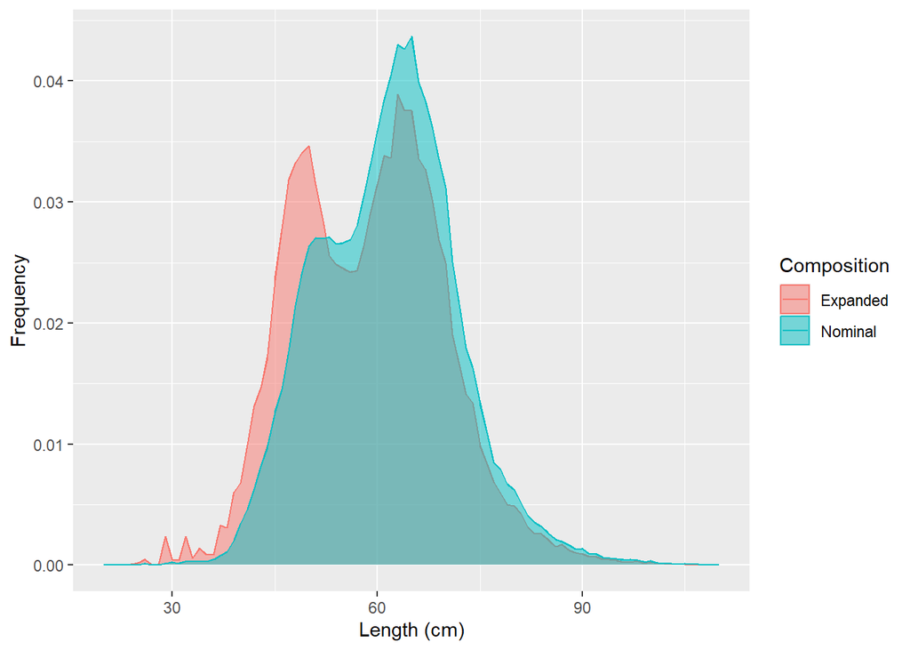

```r
df.temp = df
df.temp$type[df.temp$type=="Nom"] = "Nominal"
df.temp$type[df.temp$type=="Exp"] = "Expanded"
df.temp %>%
  tidytable::rename("Composition" = type) -> df.temp

ggplot(data=df.temp, aes(x=bin, y=freq, colour=Composition)) +
  geom_line() +
  geom_area(aes(fill=Composition, group=Composition), alpha = 0.5, position = "identity") +
  scale_x_continuous(limits = c(20, 110)) +
  labs(x = "Length (cm)", y = "Frequency")
```

## Explore 2011 difference

In 2011, there is a big hump in the expanded proportions that doesn’t exist in the nominal proportions. Can I identify what data is contributing to this hump? It is between 40-55 cm length bins. Perhaps there are massive hauls that collect these length bins in a disproportionate quantity to the primary length bin (60-75).

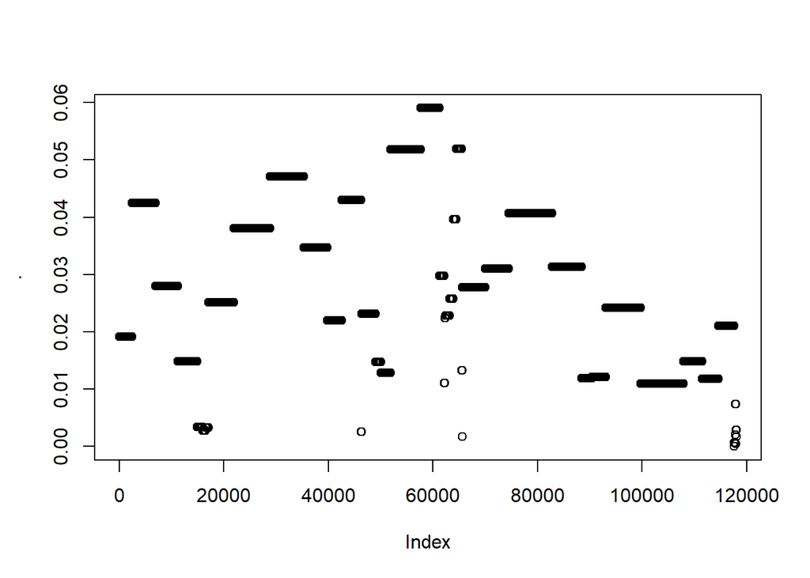

```r
y2.2011 = y2[YEAR==2011,]


# find the obs with really high weight4
y2.2011$WEIGHT4 %>% plot
```

```r
y2.2011$WEIGHT4 %>% max -> temp

y2.2011[WEIGHT4==temp, unique(YAGM_SNUM)]
```

```
## [1] 12270529
```

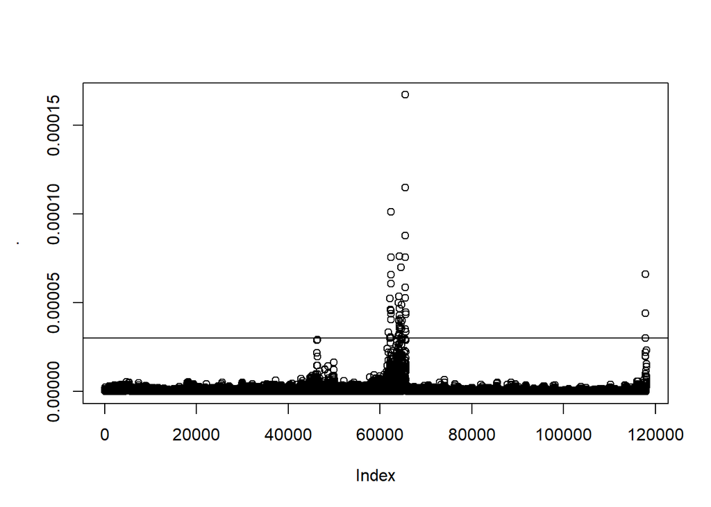

```r
y3 = y2.2011
y3$WEIGHTX<-y3$WEIGHT1*y3$WEIGHT2*y3$WEIGHT4

y3[, WEIGHTX] %>% plot
abline(h = .00003)
```

```r
y3[WEIGHTX==max(WEIGHTX),]
```

```
## Key: <SPECIES, YEAR, AREA2, GEAR, MONTH>
##    SPECIES  YEAR AREA2   GEAR MONTH CRUISE VES_AKR_ADFG             HAUL_JOIN
##      <num> <num> <num> <char> <num>  <num>        <num>                <char>
## 1:     202  2011   510    TRW    11  14581         8500 H14581002733000004224
##    LENGTH YAGMH_STONS YAGMH_SNUM SUM_FREQUENCY YAGMH_SFREQ YAGM_STONS YAGM_SNUM
##     <num>       <num>      <num>         <num>       <num>      <num>     <num>
## 1:     29     1.87054       1260             1           1   160.4215    100058
##    YAGM_SFREQ YAG_STONS YAG_SNUM YAG_SFREQ YG_STONS  YG_SNUM YG_SFREQ Y_STONS
##         <num>     <num>    <num>     <num>    <num>    <num>    <num>   <num>
## 1:         95  175152.3 62554660     22037 175531.9 62759226    22312 1078653
##       Y_SNUM Y_SFREQ YAGM_TONS YAGM_TNUM YAG_TONS YAG_TNUM  YG_TONS  YG_TNUM
##        <num>   <num>     <num>     <num>    <num>    <num>    <num>    <num>
## 1: 365963359  165819  1591.505   1009232 60846.65 26024944 63929.34 27640526
##      Y_TONS   Y_TNUM WEIGHT1   WEIGHT2    WEIGHT3    WEIGHT4      WEIGHTX
##       <num>    <num>   <num>     <num>      <num>      <num>        <num>
## 1: 208695.9 76086710       1 0.0125927 0.03651275 0.01326423 0.0001670324
```

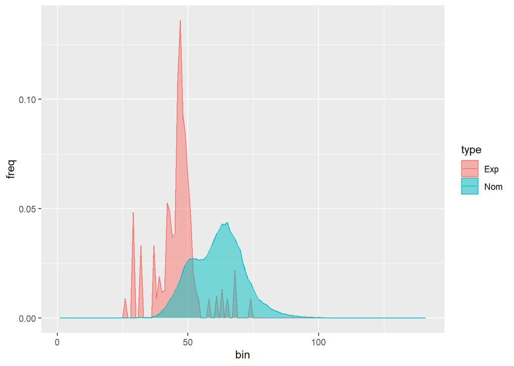

```r
y3[WEIGHTX>.00003,] -> y3.biggest.weightx



## Plot the large values distribution compared to the nominal
  y4<-y3.biggest.weightx[YAGM_SFREQ>30][,list(WEIGHT=sum(WEIGHTX)),by=c("LENGTH","YEAR")]  ## setting minumal sample size to 30 lengths for Year, area, gear, month strata. # sample size here means haul numbers of fish, not observer sample number. this reduced nrow by about 1000. this line also creates a new variable WEIGHT, which is the sum of WEIGHTX across length and year. i.e., the weight of each length for every year.

  y5<-y4[,list(TWEIGHT=sum(WEIGHT)),by=c("YEAR")] # TWEIGHT is I think the total weight summed across length bins for every year. sum(TWEIGHT) = 1.9. Shouldn't this sum to 1??
  y5=merge(y4,y5) # merge the individual length weights with their respective year weights.
  y5$FREQ<-y5$WEIGHT/y5$TWEIGHT # RESULT! This is the preliminary proportions at length. They sum to 1 for every year. the FREQuency, or relative weight, between length bins to the total annual weight.
  y6<-y5[,-c("WEIGHT","TWEIGHT")] # saving a version with just FREQ

  grid<-data.table::data.table(expand.grid(YEAR=unique(y5$YEAR),LENGTH=1:141)) # make a grid for every year, have a length bin by centemeter from 1 to max length
  y7.exp.2<-merge(grid,y6,all.x=TRUE,by=c("YEAR","LENGTH")) # merge the grid with y6, which is the expanded frequency of proportions for each length bin observed for each year.
y7.exp.2[is.na(FREQ)]$FREQ <-0                                  # RESULT! ## this is the proportion at length for an aggregated-gear fishery. # The NAs are where there were no observations for that length bin in that year so call them zero. This is what must be input into the assessment model.

df2 = df
df2[df2$type=="Exp", "freq"] = y7.exp.2$FREQ

ggplot(data=df2, aes(x=bin, y=freq, colour=type)) +
  geom_line() +
  geom_area(aes(fill=type, group=type), alpha = 0.5, position = "identity")
```

Conclusion: these look like the culprits. The high WeightX values over .00003 have a high leverage on the proportions at length where all the WeightX values exceed the nominal proportions by a large degree. This occurs at 40-55cm.

Let’s explore these observations

```r
summary(y3$WEIGHT1)
```

```
##    Min. 1st Qu.  Median    Mean 3rd Qu.    Max.
## 0.01220 0.05000 0.05000 0.07302 0.10000 1.00000
```

```r
summary(y3.biggest.weightx$WEIGHT1) # higher median - 3x
```

```
##    Min. 1st Qu.  Median    Mean 3rd Qu.    Max.
##  0.0800  0.1200  0.1765  0.2444  0.2727  1.0000
```

```r
summary(y3$WEIGHT2)
```

```
##      Min.   1st Qu.    Median      Mean   3rd Qu.      Max.
## 3.400e-07 1.184e-04 1.948e-04 4.066e-04 3.201e-04 9.110e-02
```

```r
summary(y3.biggest.weightx$WEIGHT2) # way higher median - 80x
```

```
##      Min.   1st Qu.    Median      Mean   3rd Qu.      Max.
## 0.0005924 0.0047130 0.0148699 0.0190395 0.0223558 0.0910975
```

```r
summary(y3$WEIGHT4)
```

```
##      Min.   1st Qu.    Median      Mean   3rd Qu.      Max.
## 4.790e-06 1.912e-02 2.802e-02 2.941e-02 4.070e-02 5.904e-02
```

```r
summary(y3.biggest.weightx$WEIGHT4) # same median
```

```
##     Min.  1st Qu.   Median     Mean  3rd Qu.     Max.
## 0.001744 0.013264 0.022398 0.025347 0.039616 0.051908
```

```r
# so weight2 has the highest leverage by far.
```

## check other combinations of weights to see where the highest are.

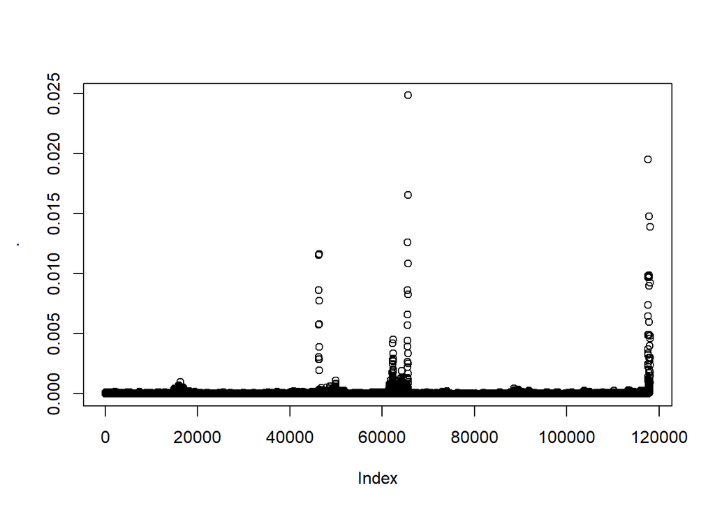

```r
y3$WEIGHTX.1.2 = y3$WEIGHT1*y3$WEIGHT2
y3[, WEIGHTX.1.2] %>% plot
```

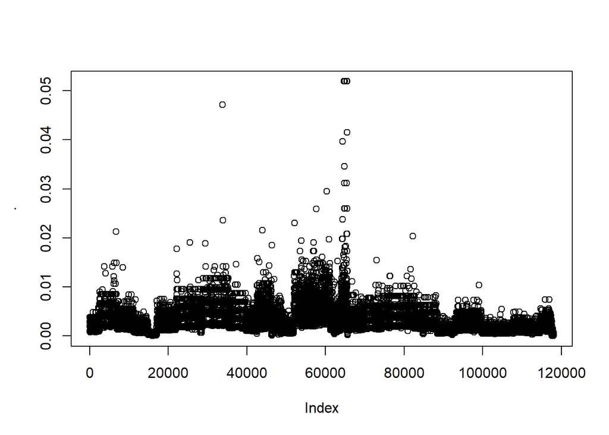

```r
y3$WEIGHTX.1.4 = y3$WEIGHT1*y3$WEIGHT4
y3[, WEIGHTX.1.4] %>% plot
```

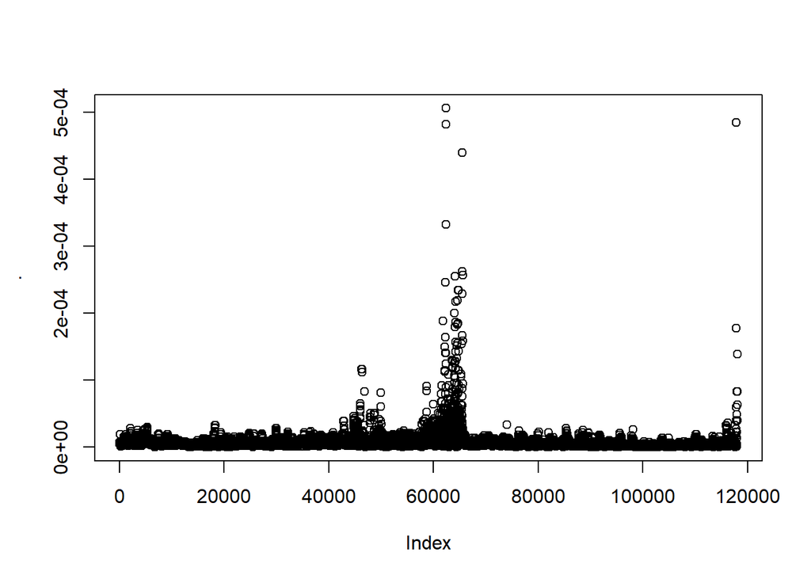

```r
y3$WEIGHTX.2.4 = y3$WEIGHT2*y3$WEIGHT4
y3[, WEIGHTX.2.4] %>% plot
```

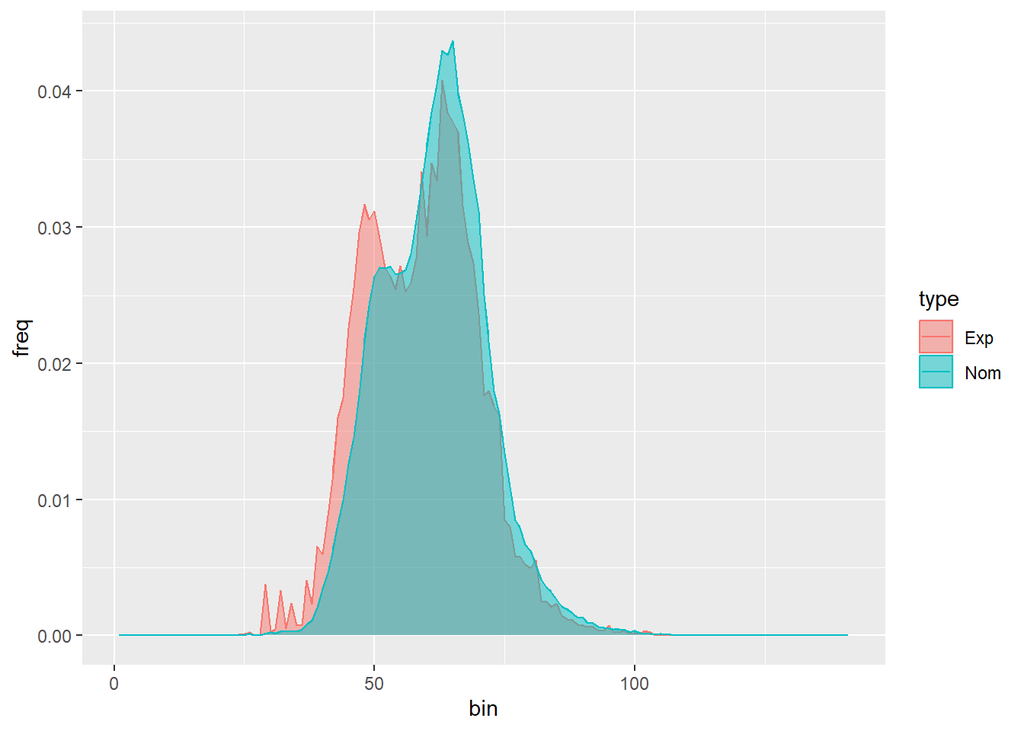

```r
# highest all in the same place

# lets plot the distribution of all these compared to nominal.
# make a function:

# Plot the large values distribution compared to the nominal

# testing
y3.subset = y3
weightx.name = "WEIGHTX"
comp_2_distributions = function(y3.subset, weightx.name){
  y4.intermediate<-y3.subset[YAGM_SFREQ>30]
  y4 = y4.intermediate[,list(WEIGHT=sum(.SD)), .SDcols = weightx.name, by=c("LENGTH","YEAR")]  ## setting minumal sample size to 30 lengths for Year, area, gear, month strata. # sample size here means haul numbers of fish, not observer sample number. this reduced nrow by about 1000. this line also creates a new variable WEIGHT, which is the sum of WEIGHTX across length and year. i.e., the weight of each length for every year.

  y5<-y4[,list(TWEIGHT=sum(WEIGHT)),by=c("YEAR")] # TWEIGHT is I think the total weight summed across length bins for every year. sum(TWEIGHT) = 1.9. Shouldn't this sum to 1??
  y5=merge(y4,y5) # merge the individual length weights with their respective year weights.
  y5$FREQ<-y5$WEIGHT/y5$TWEIGHT # RESULT! This is the preliminary proportions at length. They sum to 1 for every year. the FREQuency, or relative weight, between length bins to the total annual weight.
  y6<-y5[,-c("WEIGHT","TWEIGHT")] # saving a version with just FREQ

  grid<-data.table::data.table(expand.grid(YEAR=unique(y5$YEAR),LENGTH=1:141)) # make a grid for every year, have a length bin by centemeter from 1 to max length
  y7.exp.2<-merge(grid,y6,all.x=TRUE,by=c("YEAR","LENGTH")) # merge the grid with y6, which is the expanded frequency of proportions for each length bin observed for each year.
y7.exp.2[is.na(FREQ)]$FREQ <-0                                  # RESULT! ## this is the proportion at length for an aggregated-gear fishery. # The NAs are where there were no observations for that length bin in that year so call them zero. This is what must be input into the assessment model.

df2 = df
df2[df2$type=="Exp", "freq"] = y7.exp.2$FREQ

gp = ggplot(data=df2, aes(x=bin, y=freq, colour=type)) +
  geom_line() +
  geom_area(aes(fill=type, group=type), alpha = 0.5, position = "identity")

return(gp)
}

comp_2_distributions(y3, "WEIGHTX.1.2")
```

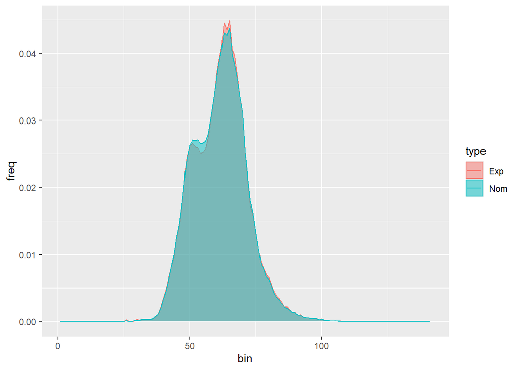

```r
comp_2_distributions(y3, "WEIGHTX.1.4")
```

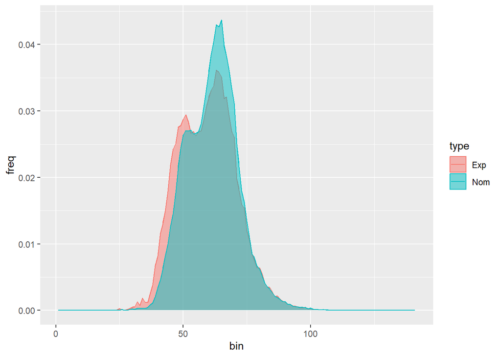

```r
comp_2_distributions(y3, "WEIGHTX.2.4")
```

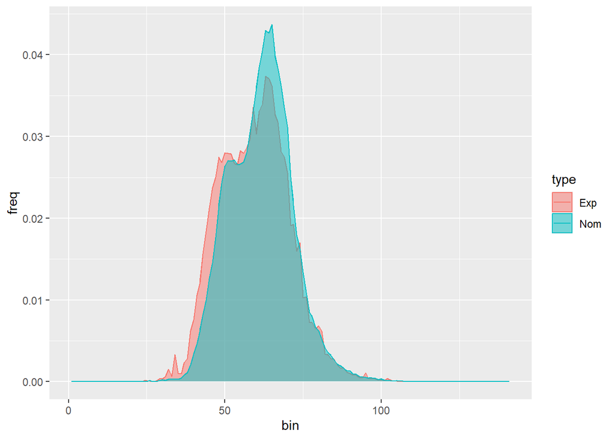

```r
comp_2_distributions(y3, "WEIGHT2")
```

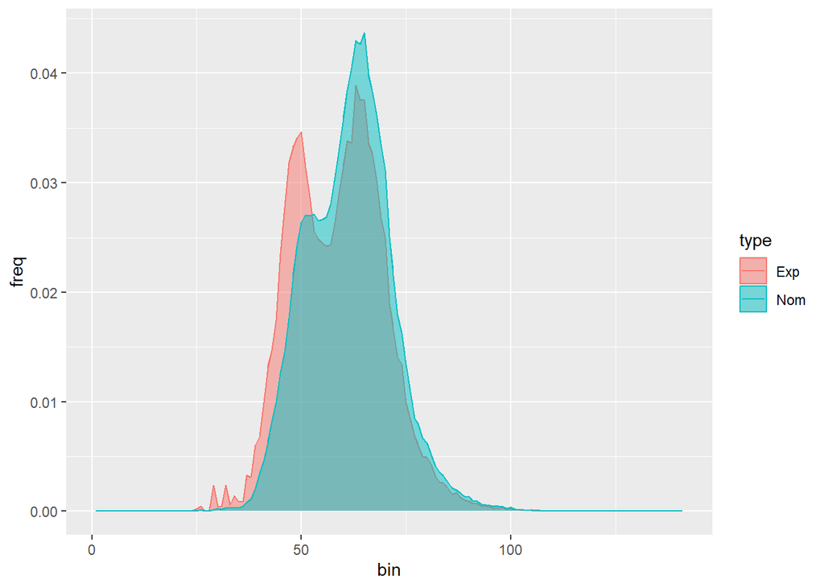

```r
comp_2_distributions(y3, "WEIGHTX")
```

Conclusion: This shows that weight2 is largely responsible for the exaggerated hump around 40-55cm. This means that there were hauls that contributed a lot to the AGM group. This could mean that there were just few hauls in that group. This may be an important part of the data to represent with another hump because it could be capturing cohort detection better than just using the nominal data. Essentially, this area, gear, month group caught more fish in this length range than the average throughout the year.

# Inspect high leverage weightx more

```r
y3.biggest.weightx$AREA2 %>% unique
```

```
## [1] 510 520
```

```r
y3.biggest.weightx$GEAR %>% unique
```

```
## [1] "TRW"
```

```r
y3.biggest.weightx$MONTH %>% unique
```

```
## [1]  4  5  6  9 10 11 12  2  3
```

```r
y3.biggest.weightx$LENGTH %>% summary
```

```
##    Min. 1st Qu.  Median    Mean 3rd Qu.    Max.
##   26.00   44.50   47.00   47.69   50.00   74.00
```

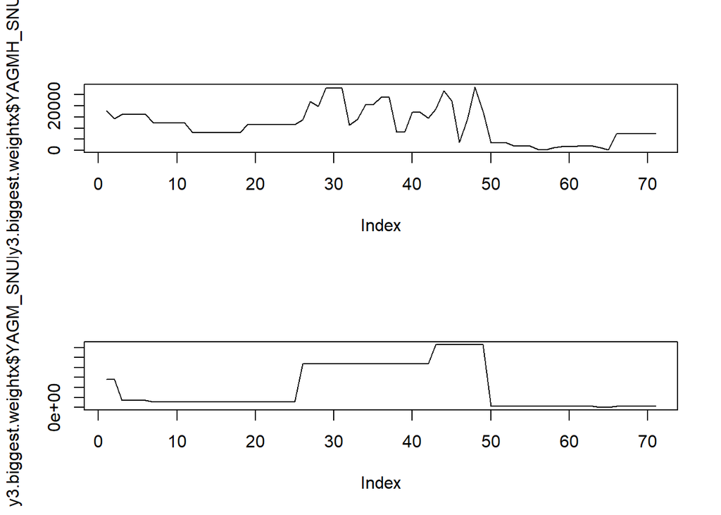

```r
par(mfrow = c(2,1))
plot(y3.biggest.weightx$YAGMH_SNUM, type = "l")
plot(y3.biggest.weightx$YAGM_SNUM, type = "l")
```

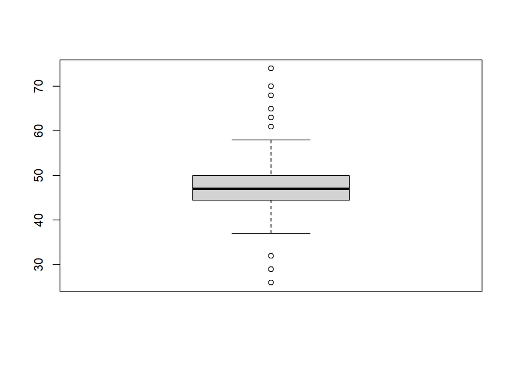

```r
par(mfrow = c(1,1))
boxplot(y3.biggest.weightx$LENGTH)
```

```r
# what's special about the biggest one?
y3.biggest.weightx[WEIGHTX==max(WEIGHTX), .(AREA2, GEAR, MONTH, YAGMH_SNUM, YAGM_SNUM, LENGTH)]
```

```
##    AREA2   GEAR MONTH YAGMH_SNUM YAGM_SNUM LENGTH
##    <num> <char> <num>      <num>     <num>  <num>
## 1:   510    TRW    11       1260    100058     29
```

```r
y3.biggest.weightx[WEIGHT2>.06, .(AREA2, GEAR, MONTH, YAGMH_SNUM, YAGM_SNUM, LENGTH, SUM_FREQUENCY)]
```

```
##    AREA2   GEAR MONTH YAGMH_SNUM YAGM_SNUM LENGTH SUM_FREQUENCY
##    <num> <char> <num>      <num>     <num>  <num>         <num>
## 1:   510    TRW    12       1231     13513     70             3
## 2:   520    TRW     3       7427    112645     39             3
## 3:   520    TRW     3       7427    112645     43             3
## 4:   520    TRW     3       7427    112645     44             2
## 5:   520    TRW     3       7427    112645     45             2
## 6:   520    TRW     3       7427    112645     47             2
## 7:   520    TRW     3       7427    112645     48             2
```

```r
y3[WEIGHT2>.06, .(AREA2, GEAR, MONTH, YAGMH_SNUM, YAGM_SNUM, LENGTH, SUM_FREQUENCY)]
```

```
##     AREA2   GEAR MONTH YAGMH_SNUM YAGM_SNUM LENGTH SUM_FREQUENCY
##     <num> <char> <num>      <num>     <num>  <num>         <num>
##  1:   510    TRW    12       1231     13513     61             1
##  2:   510    TRW    12       1231     13513     65             2
##  3:   510    TRW    12       1231     13513     68             1
##  4:   510    TRW    12       1231     13513     70             3
##  5:   510    TRW    12       1231     13513     49             1
##  6:   510    TRW    12       1231     13513     52             1
##  7:   510    TRW    12       1231     13513     69             1
##  8:   510    TRW    12       1231     13513     73             1
##  9:   520    POT     4        612      8955     71             1
## 10:   520    POT     4        612      8955     48             1
## 11:   520    POT     4        612      8955     64             1
## 12:   520    POT     4        612      8955     59             1
## 13:   520    POT     4        612      8955     67             4
```

[output cut: 41 more lines]

```r
y3[AREA2==520 & GEAR=="TRW" & MONTH==3, .(AREA2, GEAR, MONTH, YAGMH_SNUM, YAGM_SNUM, LENGTH, SUM_FREQUENCY)]
```

```
##     AREA2   GEAR MONTH YAGMH_SNUM YAGM_SNUM LENGTH SUM_FREQUENCY
##     <num> <char> <num>      <num>     <num>  <num>         <num>
##  1:   520    TRW     3       7427    112645     34             1
##  2:   520    TRW     3       7427    112645     39             3
##  3:   520    TRW     3       7427    112645     40             1
##  4:   520    TRW     3       7427    112645     41             1
##  5:   520    TRW     3       7427    112645     43             3
##  6:   520    TRW     3       7427    112645     44             2
##  7:   520    TRW     3       7427    112645     45             2
##  8:   520    TRW     3       7427    112645     46             1
##  9:   520    TRW     3       7427    112645     47             2
## 10:   520    TRW     3       7427    112645     48             2
## 11:   520    TRW     3       7427    112645     51             1
## 12:   520    TRW     3       7427    112645     56             1
## 13:   520    TRW     3       7427    112645     57             1
```

[output cut: 24 more lines]

Conclusion: I don’t really know what’s special about these area, gear, month combinations.

# Plot several years with large weightx leverage in the 40-55 range

include relative weight of weights1,2,4? can add as text on the plots.

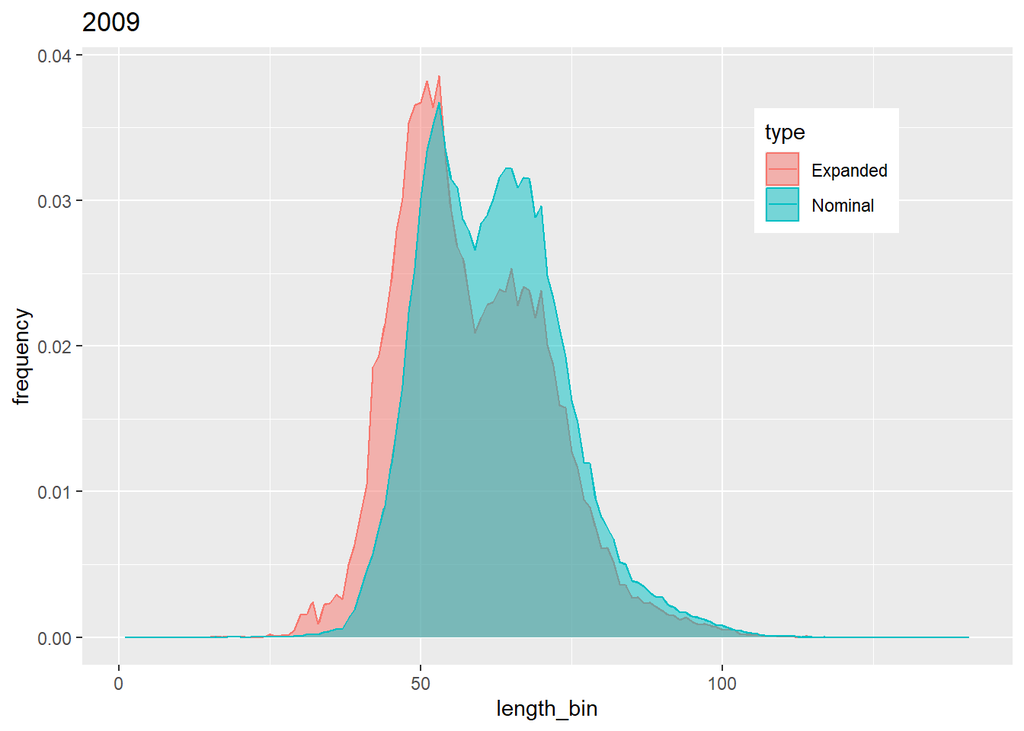

```r
# function for calculating final proportions by year




comp_2_distributions2 = function(y2, y7.nom, year, weightx.name){
  y3 = y2[YEAR==year,]
  y3$WEIGHTX<-y3$WEIGHT1*y3$WEIGHT2*y3$WEIGHT4
  y4.intermediate<-y3[YAGM_SFREQ>30]
  y4 = y4.intermediate[,list(WEIGHT=sum(.SD)), .SDcols = weightx.name, by=c("LENGTH","YEAR")]  ## setting minumal sample size to 30 lengths for Year, area, gear, month strata. # sample size here means haul numbers of fish, not observer sample number. this reduced nrow by about 1000. this line also creates a new variable WEIGHT, which is the sum of WEIGHTX across length and year. i.e., the weight of each length for every year.

  y5<-y4[,list(TWEIGHT=sum(WEIGHT)),by=c("YEAR")] # TWEIGHT is I think the total weight summed across length bins for every year. sum(TWEIGHT) = 1.9. Shouldn't this sum to 1??
  y5=merge(y4,y5) # merge the individual length weights with their respective year weights.
  y5$FREQ<-y5$WEIGHT/y5$TWEIGHT # RESULT! This is the preliminary proportions at length. They sum to 1 for every year. the FREQuency, or relative weight, between length bins to the total annual weight.
  y6<-y5[,-c("WEIGHT","TWEIGHT")] # saving a version with just FREQ

  grid<-data.table::data.table(expand.grid(YEAR=unique(y5$YEAR),LENGTH=1:141)) # make a grid for every year, have a length bin by centemeter from 1 to max length
  y7.exp.2<-merge(grid,y6,all.x=TRUE,by=c("YEAR","LENGTH")) # merge the grid with y6, which is the expanded frequency of proportions for each length bin observed for each year.
y7.exp.2[is.na(FREQ)]$FREQ <-0                                  # RESULT! ## this is the proportion at length for an aggregated-gear fishery. # The NAs are where there were no observations for that length bin in that year so call them zero. This is what must be input into the assessment model.

expanded = y7.exp.2[YEAR==year, ]
nominal = y7.nom[YEAR==year, ]

df2 = data.frame(type = rep(c("Nominal", "Expanded"), each = nrow(grid)),
                length_bin = rep(expanded$LENGTH, 2),
                frequency = c(nominal$FREQ, expanded$FREQ))



gp = ggplot(data=df2, aes(x=length_bin, y=frequency, colour=type)) +
  geom_line() +
  geom_area(aes(fill=type, group=type), alpha = 0.5, position = "identity") +
  ggtitle(year) +
  theme(legend.position = "inside") +
  theme(legend.position.inside = c(0.8, 0.8))

return(gp)
}



comp_2_distributions2(y2, y7.nom, 2009, "WEIGHTX")
```

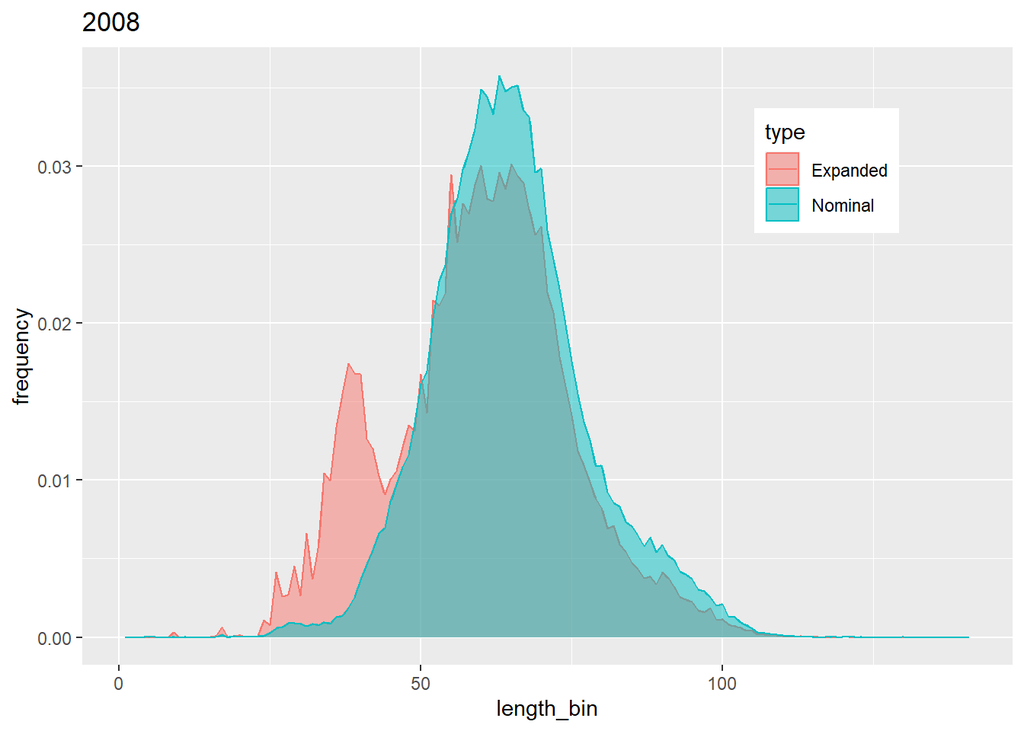

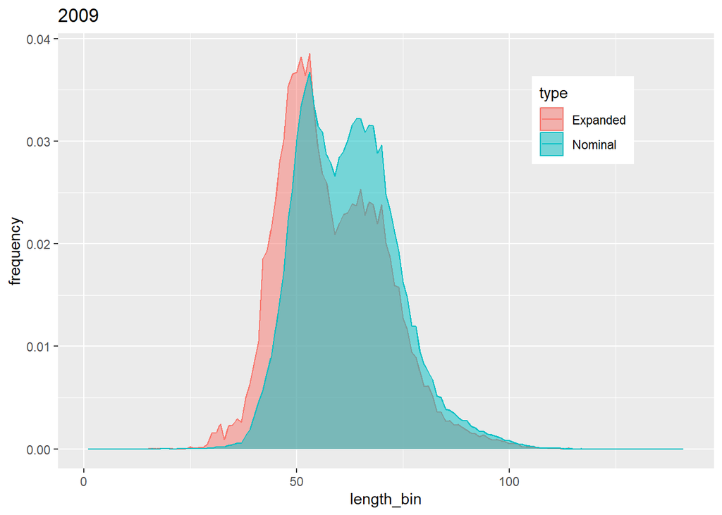

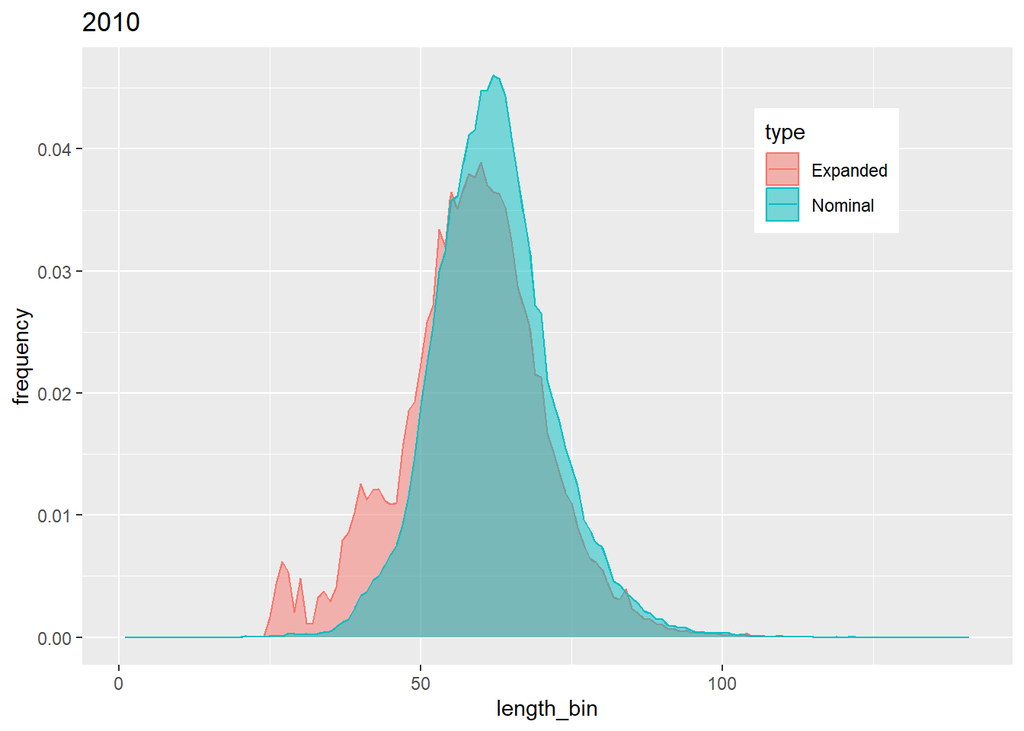

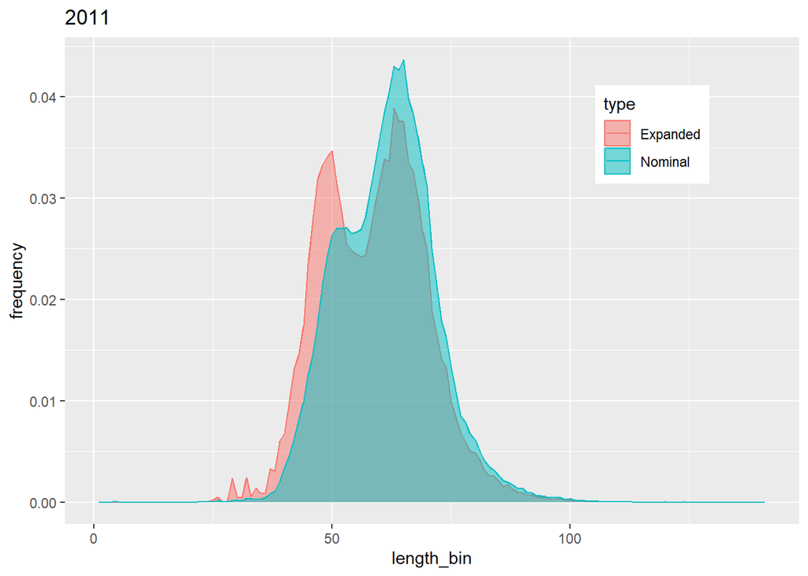

```r
purrr::map(2008:2011, ~comp_2_distributions2(y2, y7.nom, .x, "WEIGHTX"))
```

## Problem?

are hauls with more observations getting more weight in weight2?

For weight2 calculation, the number of fish from all hauls are added up, and the numbers from each haul are divided by the total. But the problem is, each length observation category lists the haul total in YAGMH. So the more observations, the greater the contribution to the total sum.

```r
y2.2011.hauls = y2.2011 %>%
  tidytable::distinct(HAUL_JOIN, .keep_all = T) %>%
  data.table()

y2.2011.hauls
```

```
##       SPECIES  YEAR AREA2   GEAR MONTH CRUISE VES_AKR_ADFG
##         <num> <num> <num> <char> <num>  <num>        <num>
##    1:     202  2011   510    HAL     1  13862         4573
##    2:     202  2011   510    HAL     1  13862         4573
##    3:     202  2011   510    HAL     1  13862         4573
##    4:     202  2011   510    HAL     1  13862         4573
##    5:     202  2011   510    HAL     1  13862         4573
##   ---
## 8616:     202  2011   520    TRW     7  14368         1610
## 8617:     202  2011   520    TRW     7  14400         3369
## 8618:     202  2011   520    TRW     7  14400         3369
## 8619:     202  2011   520    TRW     7  14408         2924
## 8620:     202  2011   520    TRW     8  14314         3442
##                   HAUL_JOIN LENGTH YAGMH_STONS YAGMH_SNUM SUM_FREQUENCY
##                      <char>  <num>       <num>      <num>         <num>
```

[output cut: 63 more lines]

```r
# well, let's calculate the weights by unique hauls and compare it to what is already done.


y2[,sum(WEIGHT2), by=YAGM_SNUM]
```

```
##        YAGM_SNUM    V1
##            <num> <num>
##    1: 1567083.01     1
##    2: 2613477.03     1
##    3:   66902.94     1
##    4:   63613.91     1
##    5: 1477582.17     1
##   ---
## 1459:   61638.00     1
## 1460:  106288.00     1
## 1461:   30905.00     1
## 1462:    1391.00     1
## 1463:    5413.00     1
```

```r
y2.2011[,sum(WEIGHT2), by=YAGM_SNUM]
```

```
##     YAGM_SNUM    V1
##         <num> <num>
##  1:  10406384     1
##  2:  19721611     1
##  3:  14540416     1
##  4:   8839540     1
##  5:   2675066     1
##  6:   1542056     1
##  7:   1045922     1
##  8:  15907979     1
##  9:  23143862     1
## 10:  19946491     1
## 11:  13566215     1
## 12:   8472791     1
## 13:  10154861     1
```

[output cut: 36 more lines]

```r
y2.2011.hauls[,sum(WEIGHT2), by=YAGM_SNUM]
```

```
##     YAGM_SNUM         V1
##         <num>      <num>
##  1:  10406384 0.06915976
##  2:  19721611 0.07019026
##  3:  14540416 0.07103249
##  4:   8839540 0.07235716
##  5:   2675066 0.07044275
##  6:   1542056 0.07138457
##  7:   1045922 0.07345290
##  8:  15907979 0.07056270
##  9:  23143862 0.07055473
## 10:  19946491 0.07399377
## 11:  13566215 0.07577176
## 12:   8472791 0.07246030
## 13:  10154861 0.07865711
```

[output cut: 36 more lines]

```r
# something is wrong here
y2.2011[AREA2==unique(AREA2)[1] & GEAR==unique(GEAR)[1] & MONTH==unique(MONTH)[1], YAGMH_SNUM] %>% sum()
```

```
## [1] 10406384
```

```r
y2.2011[1, YAGM_SNUM]
```

```
## [1] 10406384
```

```r
# I think if I for example added another observation to a haul, it would change the weight2, which is unintentional. It shouldn't change weight2.




x = c(3,3,3,4,4)


y = c(3,4)/7
y[1]/y[2]
```

```
## [1] 0.75
```

```r
z = x/sum(x)

z[1]/z[4]
```

```
## [1] 0.75
```

Conclusion: I don’t think there is a problem. Based on the pretend data above, the ratios of the proportions between distinct values are the same whether values are repeated or not. I think this means that the YAGMH values being repeated for all distinct length measurements in a haul isn’t an issue.